# presentacion_clase_47 slides

[figure not shown]

DATA SCIENCE

MÓDULO 6

Text Minig  
Clasificación de texto

## Agenda

- Análisis de sentimientos como problema de clasificación
- Clasificación
- N-gramas

Introducción

[figure not shown]

## Introducción

El análisis de sentimientos es una técnica a través de la cual podemos analizar un fragmento de texto para determinar el sentimiento detrás de él.  
Combina el aprendizaje automático y el procesamiento del lenguaje natural (NLP) para lograrlo.  
Podemos pensar este problema como un problema de clasificación, donde las features son generadas con el técnicas de preprocesamiento de texto que vimos la clase pasada.

[figure not shown]

Clasificación

[figure not shown]

## Clasificación

En esta clase analizaremos un dataset de reviews de imdb (http://ai.stanford.edu/~amaas/data/sentiment/) usando regresión logística para predecir a partir del texto del comentario si la calificación otorgada por el usuario es positiva o negativa.

### Datos

Los datos están separados en dos archivos, uno de train y uno de test, cada uno con la misma cantidad de registros.

Las clases están balanceadas tanto en el dataset de train como en el de test, es decir, hay igual cantidad de reviews positivas y negativas.

```python
train_file_path = '../Data/imdb_train.zip'
data_train = pd.read_csv(train_file_path, sep="\t")
data_train
```

|  | text | label |
| --- | --- | --- |
| 0 | Bromwell High is a cartoon comedy. It ran at t... | 1 |
| 1 | Homelessness (or Houselessness as George Carli... | 1 |
| 2 | Brilliant over-acting by Lesley Ann Warren. Be... | 1 |
| 3 | This is easily the most underrated film inn th... | 1 |
| 4 | This is not the typical Mel Brooks film. It wa... | 1 |
| ... | ... | ... |
| 24995 | Towards the end of the movie, I felt it was to... | 0 |
| 24996 | This is the kind of movie that my enemies cont... | 0 |
| 24997 | I saw 'Descent' last night at the Stockholm Fi... | 0 |
| 24998 | Some films that you pick up for a pound turn o... | 0 |
| 24999 | This is one of the dumbest films, I've ever se... | 0 |

25000 rows × 2 columns

```python
data_train.label.value_counts()
```

```
1    12500
0    12500
Name: label, dtype: int64
```

```python
test_file_path = '../Data/imdb_test.zip'
data_test = pd.read_csv(test_file_path, sep="\t")
data_test
```

|  | text | label |
| --- | --- | --- |
| 0 | I went and saw this movie last night after bei... | 1 |
| 1 | Actor turned director Bill Paxton follows up h... | 1 |
| 2 | As a recreational golfer with some knowledge o... | 1 |
| 3 | I saw this film in a sneak preview, and it is ... | 1 |
| 4 | Bill Paxton has taken the true story of the 19... | 1 |
| ... | ... | ... |
| 24995 | I occasionally let my kids watch this garbage ... | 0 |
| 24996 | When all we have anymore is pretty much realit... | 0 |
| 24997 | The basic genre is a thriller intercut with an... | 0 |
| 24998 | Four things intrigued me as to this film - fir... | 0 |
| 24999 | David Bryce's comments nearby are exceptionall... | 0 |

25000 rows × 2 columns

```python
data_test.label.value_counts()
```

```
1    12500
0    12500
Name: label, dtype: int64
```

### Imports

```python
from nltk import RegexpTokenizer
from nltk.stem.snowball import SnowballStemmer
from nltk.corpus import stopwords
from sklearn.feature_extraction.text import CountVectorizer
```

### Preparación

Limpiamos los datos de train y de test:

- usamos un tokennizer que elimine los signos de puntuación y tags html
- hacemos stemming para obtener las raíces de las palabras en minúsculas
- eliminamos stopwords

```python
def clean_review(review_text, tokenizer, stemmer, stopwords):

    #tokens (eliminamos todos los signos de puntuación)
    words = tokenizer.tokenize(review_text)
    #print(words)

    # stemming: raiz y minúsculas:
    stem_words = [stemmer.stem(x) for x in words]
    #print(stem_words)

    # eliminamos stopwords (ya pasaron por stem)
    clean_words = [x for x in stem_words if x not in stopwords]
    #print(clean_words)

    result = " ".join(clean_words)

    return(result)
```

Ejemplo sobre un registro de train

```python
review_text = data_train.text[1]

print("antes: ", review_text)

#eliminamos todos los signos de puntuación
tokenizer = RegexpTokenizer(r"\w+")

englishStemmer = SnowballStemmer("english")
stopwords_en = stopwords.words('english');
stopwords_en_stem = [englishStemmer.stem(x) for x in stopwords_en]

review_text_clean = clean_review(review_text, tokenizer, englishStemmer, stopwords_en_stem)
```

```
antes:  Homelessness (or Houselessness as George Carlin stated) has been an issue for years but never a plan to help those on the street that were once considered human who did everything from going to school, work, or vote for the matter. Most people think of the homeless as just a lost cause while…
```

```python
print("---")
print("después: ", review_text_clean)
```

```
---
después:  homeless houseless georg carlin state issu year never plan help street consid human everyth go school work vote matter peopl think homeless lost caus worri thing racism war iraq pressur kid succeed technolog elect inflat worri next end street br br given bet live street month without luxur…
```

Procesamos todos los registros de los datasets de train y test

```python
clean_train = [clean_review(x, tokenizer, englishStemmer, stopwords_en_stem) for x in data_train.text]
#clean_train[0:5]
```

```python
clean_test = [clean_review(x, tokenizer, englishStemmer, stopwords_en_stem) for x in data_test.text]
#clean_test[0:5]
```

Usando `CountVectorizer` vamos a transformar los datos de train y test

```python
count_vectorizer = CountVectorizer()
count_vectorizer.fit(clean_train)
X_train_sparse = count_vectorizer.transform(clean_train)
X_test_sparse = count_vectorizer.transform(clean_test)
```

```python
X_train = pd.DataFrame(X_train_sparse.todense(),
             columns = count_vectorizer.get_feature_names())
y_train = data_train.label
```

```python
X_test = pd.DataFrame(X_test_sparse.todense(),
             columns = count_vectorizer.get_feature_names())
y_test = data_test.label
```

### Modelo

Vamos a usar ahora una regresión logística para predecir el valor de `label`

```python
from sklearn.linear_model import LogisticRegression
from sklearn.metrics import accuracy_score, confusion_matrix
from sklearn.model_selection import train_test_split
```

Veamos qué valor de `C` (regularización) resulta en un modelo de mejor performance

https://scikit-learn.org/stable/modules/generated/sklearn.linear_model.LogisticRegression.html

Valores más pequeños de `C` implican regularización más fuerte.

```python
X_train_train, X_train_val, y_train_train, y_train_val = \
    train_test_split(X_train, y_train, train_size = 0.75, shuffle = True, random_state = 147)

for c in [0.005, 0.008, 0.01, 0.05, 0.25, 0.5, 1]:
    lr = LogisticRegression(C=c, solver="newton-cg", penalty="l2")
    lr.fit(X_train_train, y_train_train)
    print ("Accuracy for C=%s: %s"
           % (c, accuracy_score(y_train_val, lr.predict(X_train_val))))
```

```
Accuracy for C=0.005: 0.87024
Accuracy for C=0.008: 0.87424
Accuracy for C=0.01: 0.8744
Accuracy for C=0.05: 0.88256
Accuracy for C=0.25: 0.87712
Accuracy for C=0.5: 0.87472
Accuracy for C=1: 0.86976
```

Entrenamos el modelo final

```python
final_model = LogisticRegression(C = 0.05, solver="newton-cg", penalty="l2")
final_model.fit(X_train, y_train)
print ("Final Accuracy: %s"
        % accuracy_score(y_test, final_model.predict(X_test)))
print ("Final Confusion Matrix: \n %s"
        % confusion_matrix(y_test, final_model.predict(X_test)))
```

```
Final Accuracy: 0.87496
Final Confusion Matrix:
 [[10975  1525]
 [ 1601 10899]]
```

Observemos cuáles son las 3 palabras más discriminantes tanto positiva como negativamente.

Para ver esto, veremos cuáles son las palabras (features) asociadas a los coeficientes máximos y mínimos de la regresión logística.

Construyamos un dataframe de dos columnas:

- word: cada registro tiene un nombre que corresponde a una feature del modelo (las palabras en el corpus)
- coef: cada registro tiene un valor que es el coeficiente de la regresión logística para su feature

Y ordenemos el dataframe según los valores de coef de forma descendente.

```python
feature_to_coef = pd.DataFrame(columns = ['word', 'coef'])
feature_to_coef.word = count_vectorizer.get_feature_names()
feature_to_coef.coef = final_model.coef_[0]
feature_to_coef_sort_desc = feature_to_coef.sort_values(by = 'coef', ascending = False)
positive_words = feature_to_coef_sort_desc.word[0:3]
positive_words
```

```
15105      excel
33541    perfect
15693    favorit
Name: word, dtype: object
```

```python
feature_to_coef_sort_asc = feature_to_coef.sort_values(by = 'coef', ascending = True)
negative_words = feature_to_coef_sort_asc.word[0:3]
negative_words
```

```
49567    worst
48546     wast
3778        aw
Name: word, dtype: object
```

Grafiquemos estos resultados para ver cómo se distribuyen los valores

```python
columns =  np.concatenate([positive_words.values, negative_words.values])
columns
```

```
array(['excel', 'perfect', 'favorit', 'worst', 'wast', 'aw'], dtype=object)
```

```python
data_plot = X_train.loc[:, columns]
data_plot.reset_index(inplace = True)
data_plot["label"] = y_train
```

```python
data_plot_long = pd.melt(data_plot,
                         id_vars = ["index", "label"],
                         #value_vars = data_plot.columns[1:len(data_plot.columns)-1],
                         var_name = "word", value_name = "value")
data_plot_long["word_label"] = data_plot_long.word + ["_" + str(x) for x in data_plot_long.label]
data_plot_long
```

|  | index | label | word | value | word_label |
| --- | --- | --- | --- | --- | --- |
| 0 | 0 | 1 | excel | 0 | excel_1 |
| 1 | 1 | 1 | excel | 0 | excel_1 |
| 2 | 2 | 1 | excel | 0 | excel_1 |
| 3 | 3 | 1 | excel | 0 | excel_1 |
| 4 | 4 | 1 | excel | 0 | excel_1 |
| ... | ... | ... | ... | ... | ... |
| 149995 | 24995 | 0 | aw | 0 | aw_0 |
| 149996 | 24996 | 0 | aw | 0 | aw_0 |
| 149997 | 24997 | 0 | aw | 0 | aw_0 |
| 149998 | 24998 | 0 | aw | 2 | aw_0 |
| 149999 | 24999 | 0 | aw | 0 | aw_0 |

150000 rows × 5 columns

```python
data_plot_long.sort_values(by = "index").head()
```

|  | index | label | word | value | word_label |
| --- | --- | --- | --- | --- | --- |
| 0 | 0 | 1 | excel | 0 | excel_1 |
| 75000 | 0 | 1 | worst | 0 | worst_1 |
| 50000 | 0 | 1 | favorit | 0 | favorit_1 |
| 125000 | 0 | 1 | aw | 0 | aw_1 |
| 25000 | 0 | 1 | perfect | 0 | perfect_1 |

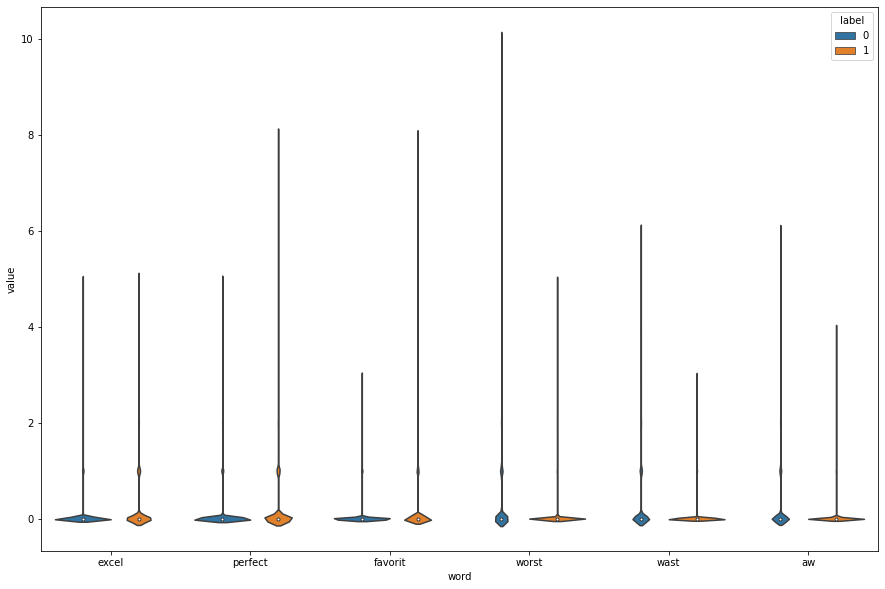

```python
plt.figure(figsize=(15,10))
sns.violinplot(x = data_plot_long.word, y = data_plot_long.value, hue = data_plot_long.label);
```

### Singular Value Decomposition

Entrenemos una regresión logística que use como features el resultado de SVD.

```python
feature_to_coef.shape
```

```
(50538, 2)
```

El modelo anterior fue entrenado con más de 50 mil features!

Veamos cómo cambia la performance seleccionando 200 features.

```python
from sklearn.decomposition import TruncatedSVD

svd = TruncatedSVD(n_components = 200);

X_train_svd = svd.fit_transform(X_train)
```

```python
X_test_svd = svd.transform(X_test)
```

```python
X_train_svd_train, X_train_svd_val, y_train_train, y_train_val = \
    train_test_split(X_train_svd, y_train, train_size = 0.75, shuffle = True, random_state = 147)

for c in [0.005, 0.008, 0.009, 0.01, 0.05, 0.07]:
    lr = LogisticRegression(C=c, solver="newton-cg", penalty="l2")
    lr.fit(X_train_svd_train, y_train_train)
    print ("Accuracy for C=%s: %s"
           % (c, accuracy_score(y_train_val, lr.predict(X_train_svd_val))))
```

```
Accuracy for C=0.005: 0.84304
Accuracy for C=0.008: 0.84528
Accuracy for C=0.009: 0.84528
Accuracy for C=0.01: 0.84544
Accuracy for C=0.05: 0.84528
Accuracy for C=0.07: 0.84608
```

```python
final_model_svd = LogisticRegression(C = 0.01, solver="newton-cg", penalty="l2")
final_model_svd.fit(X_train_svd, y_train)
print ("Final Accuracy: %s"
       % accuracy_score(y_test, final_model_svd.predict(X_test_svd)))
print ("Final Confusion Matrix: \n %s"
        % confusion_matrix(y_test, final_model_svd.predict(X_test_svd)))
```

```
Final Accuracy: 0.84732
Final Confusion Matrix:
 [[10465  2035]
 [ 1782 10718]]
```

## N-gramas

Hasta ahora usamos sólo features compuestas por una sola palabra en nuestro modelo, que llamamos **1-grama** o **unigrama**.

Potencialmente, podemos agregar más poder predictivo a nuestro modelo agregando también **secuencias de dos o tres palabras (bigramas o trigramas)**.

Por ejemplo, si una reseña tuviera la secuencia de tres palabras "no me gustó la película", solo consideraríamos estas palabras individualmente con un modelo de unigramas y probablemente no captaríamos que se trata de un sentimiento negativo porque la palabra "gustó" en sí misma va a estar altamente correlacionado con una revisión positiva.

Scikit-learn hace que sea muy fácil construir estas features.

Simplemente usamos el argumento `ngram_range` con cualquiera de las clases "Vectorizador".

```python
count_vectorizer_bigram = CountVectorizer(ngram_range = (1, 2))
count_vectorizer_bigram.fit(clean_train)
X_train_bigram_sparse = count_vectorizer_bigram.transform(clean_train)
X_test_bigram_sparse = count_vectorizer_bigram.transform(clean_test)

#X_train_bigram = pd.DataFrame(X_train_bigram_sparse.todense(),
#             columns = count_vectorizer_bigram.get_feature_names())

#X_test_bigram = pd.DataFrame(X_test_bigram_sparse.todense(),
#             columns = count_vectorizer_bigram.get_feature_names())

#usamos las matrices esparsas porque rompe si trato de convertrlas en densas para esta cantidad de features
X_train_bigram_train, X_train_bigram_val, y_train_train, y_train_val = \
    train_test_split(X_train_bigram_sparse, y_train, train_size = 0.75, shuffle = True, random_state = 147)

for c in [0.01, 0.05, 0.1, 0.25, 0.5, 0.6, 0.7, 0.8, 0.9, 1]:
    lr = LogisticRegression(C=c, solver="newton-cg", penalty="l2")
    lr.fit(X_train_bigram_train, y_train_train)
    print ("Accuracy for C=%s: %s"
           % (c, accuracy_score(y_train_val, lr.predict(X_train_bigram_val))))
```

```
Accuracy for C=0.01: 0.87824
Accuracy for C=0.05: 0.88528
Accuracy for C=0.1: 0.88768
Accuracy for C=0.25: 0.88832
Accuracy for C=0.5: 0.888
Accuracy for C=0.6: 0.88816
Accuracy for C=0.7: 0.8872
Accuracy for C=0.8: 0.8872
Accuracy for C=0.9: 0.88752
Accuracy for C=1: 0.88784
```

```python
final_model_bigram = LogisticRegression(C = 0.25, solver="newton-cg", penalty="l2")
final_model_bigram.fit(X_train_bigram_sparse, y_train)
print ("Final Accuracy: %s"
       % accuracy_score(y_test, final_model_bigram.predict(X_test_bigram_sparse)))
print ("Final Confusion Matrix: \n %s"
        % confusion_matrix(y_test, final_model_bigram.predict(X_test_bigram_sparse)))
```

```
Final Accuracy: 0.8834
Final Confusion Matrix:
 [[11040  1460]
 [ 1455 11045]]
```

Conclusiones

[figure not shown]

- Construimos un modelo de clasificación de textos empleando los algoritmos que ya conocíamos.
- Construimos el conjunto de features del modelo transformando los inputs (textos) mediante las técnicas de preprocesamiento que vimos en la clase pasada.
- Evaluamos la performance del modelo del mismo modo que lo hacemos con cualquier modelo de clasificación.

Hands-on

[figure not shown]

## Ejercicio

TF-IDF es mejor que CountVectorizer porque no sólo se centra en la frecuencia de las palabras presentes en el corpus, sino que también tiene en cuenta su importancia.

Volvamos a entrenar una regresión logísticas usando como features la representación tf-idf de unigramas, bigramas y trigramas.

Veamos cuáles son los n-gramas más discriminantes.

## Solución

```python
from sklearn.feature_extraction.text import TfidfTransformer
```

```python
count_vectorizer = CountVectorizer(ngram_range = (1, 3))
count_vectorizer.fit(clean_train)
X_train_sparse = count_vectorizer.transform(clean_train)
X_test_sparse = count_vectorizer.transform(clean_test)
```

```python
transformer = TfidfTransformer()

X_train_ngram_encoding = transformer.fit_transform(X_train_sparse);

X_test_ngram_encoding = transformer.transform(X_test_sparse);
```

```python
X_train_ngram_train, X_train_ngram_val, y_train_train, y_train_val = \
    train_test_split(X_train_ngram_encoding, y_train, train_size = 0.75, shuffle = True, random_state = 147)

for c in [0.05, 0.25, 0.5, 0.7, 0.8, 0.9, 1]:
    lr = LogisticRegression(C=c, solver="newton-cg", penalty="l2")
    lr.fit(X_train_ngram_train, y_train_train)
    print ("Accuracy for C=%s: %s"
           % (c, accuracy_score(y_train_val, lr.predict(X_train_ngram_val))))
```

```
Accuracy for C=0.05: 0.824
Accuracy for C=0.25: 0.85216
Accuracy for C=0.5: 0.86448
Accuracy for C=0.7: 0.86816
Accuracy for C=0.8: 0.86976
Accuracy for C=0.9: 0.87056
Accuracy for C=1: 0.87184
```

```python
final_model_tfidf = LogisticRegression(C = 1, solver="newton-cg", penalty="l2")
final_model_tfidf.fit(X_train_ngram_encoding, y_train)
print ("Final Accuracy: %s"
       % accuracy_score(y_test, final_model_tfidf.predict(X_test_ngram_encoding)))
print ("Final Confusion Matrix: \n %s"
        % confusion_matrix(y_test, final_model_tfidf.predict(X_test_ngram_encoding)))
```

```
Final Accuracy: 0.87268
Final Confusion Matrix:
 [[10869  1631]
 [ 1552 10948]]
```

```python
feature_to_coef = pd.DataFrame(columns = ['ngram', 'coef'])
feature_to_coef.ngram = count_vectorizer.get_feature_names()
feature_to_coef.coef = final_model_tfidf.coef_[0]
feature_to_coef_sort_desc = feature_to_coef.sort_values(by = 'coef', ascending = False)
feature_to_coef_sort_desc.ngram[0:5]
```

```
1681009      great
2262246       love
1263859      excel
383123        best
2825804    perfect
Name: ngram, dtype: object
```

```python
feature_to_coef_sort_asc = feature_to_coef.sort_values(by = 'coef', ascending = True)
feature_to_coef_sort_asc.ngram[0:5]
```

```
310981       bad
4251155    worst
4116228     wast
2923132     poor
451225      bore
Name: ngram, dtype: object
```

Vemos que los n-grams más discriminantes son unigramas

Referencias y material adicional

[figure not shown]

[How to Build a Twitter Sentiment Analysis System](https://towardsdatascience.com/how-to-build-a-twitter-sentiment-analysis-system-12b28dcbae56)

[Sentiment Analysis with Python (Part 1)](https://towardsdatascience.com/sentiment-analysis-with-python-part-1-5ce197074184)

[Sentiment Analysis with Python (Part 2)](https://towardsdatascience.com/sentiment-analysis-with-python-part-2-4f71e7bde59a)

[Performing Sentiment Analysis on Movie Reviews](https://towardsdatascience.com/imdb-reviews-or-8143fe57c825)

[Sentiment Analysis of IMDB Movie Reviews](https://www.kaggle.com/lakshmi25npathi/sentiment-analysis-of-imdb-movie-reviews)